# Reporte Temporada 2022

M. Abel Herrera

2023-11-21

# Análisis explotatorio

## Fluorescencia

La siguiente tabla presenta la cantidad de dias de muestreo, el promedio de datos recopilados en cada uno de ellos, y el total recopilado durante toda la temporada por sitio. Los datos no contienen NA’s.

```
##          sitio n_muestreos n_datos_promedio n_datos_totales
## 1 la_esperanza          16             14.6             234
## 2    rio_claro          18             14.7             264
```

A continuación se muestran los resultados de tres indicadores de fluorescencia: ΦP0 (Rendimiento Cuántico Máximo del Fotosistema II), ΦE0 (Rendimiento Cuántico Efectivo del Fotosistema II) y Ψ0 (Eficiencia Cuántica Máxima del Fotosistema II).

#### Boxplot

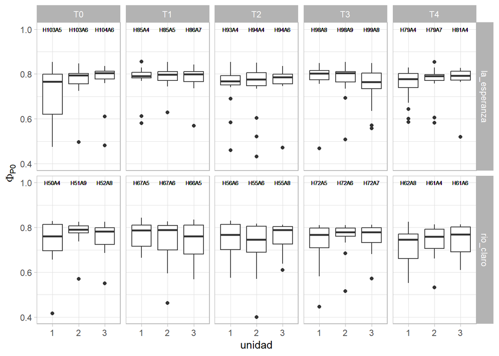

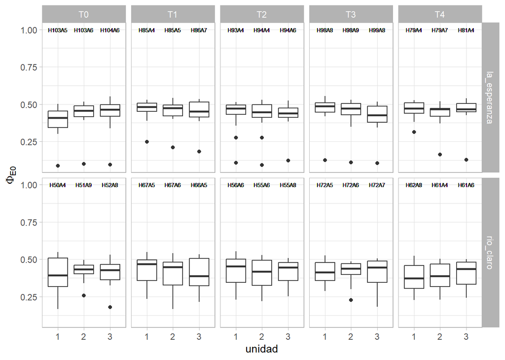

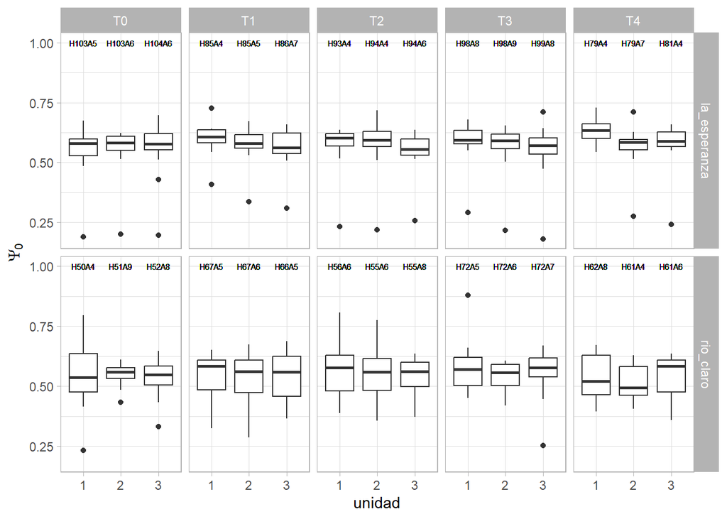

### Serie temporal

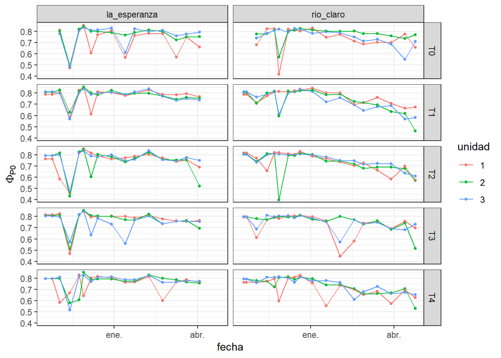

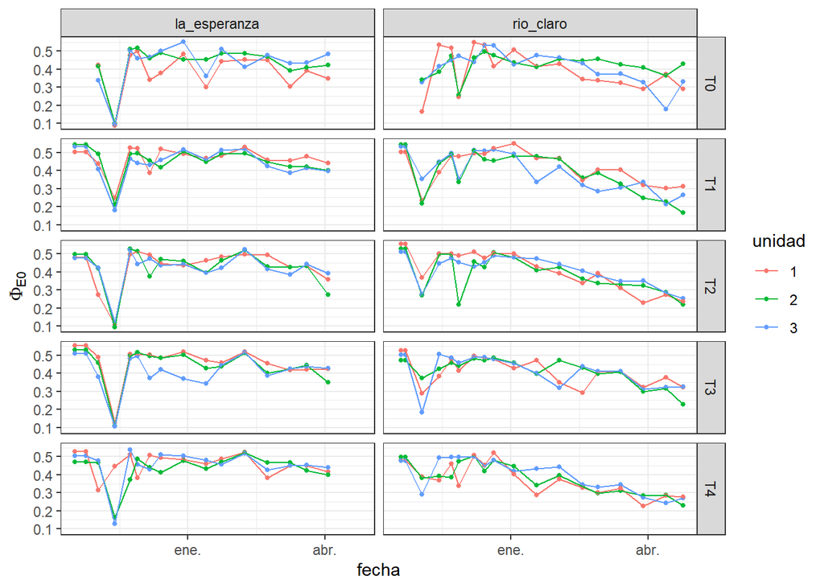

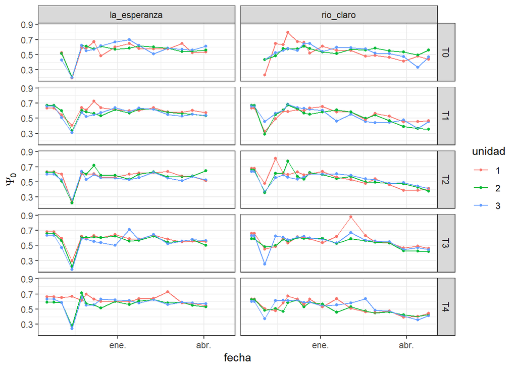

## Potencial

La siguiente tabla presenta la cantidad de días de muestreo, el promedio de datos recopilados en cada uno de ellos, y el total recopilado durante toda la temporada por sitio. Los datos no contienen NA’s.

```
##          sitio n_dias n_datos_promedio n_datos_totales
## 1 la_esperanza     12             14.7             176
## 2    rio_claro     15             14.1             212
```

### Boxplot

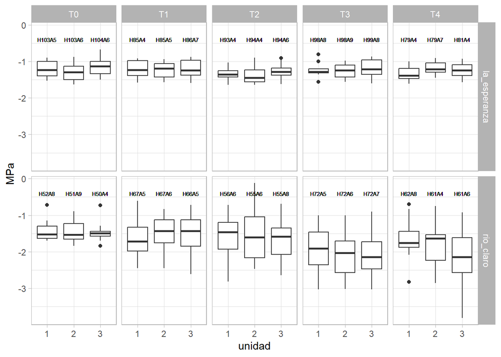

### Serie temporal

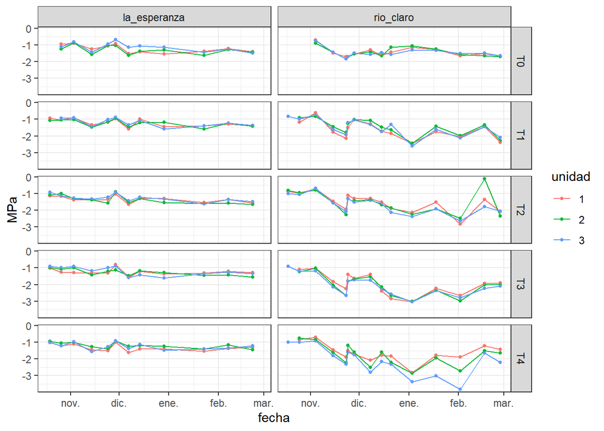

## PAR

La siguiente tabla presenta la cantidad de dias de muestreo, el promedio de datos recopilados en cada uno de ellos, y el total recopilado durante toda la temporada por sitio. Los datos no contienen NA’s.

```
##          sitio n_dias n_datos_promedios n_datos_totales
## 1 la_esperanza      8               5.6              45
## 2    rio_claro      9               5.6              50
```

### Boxplot

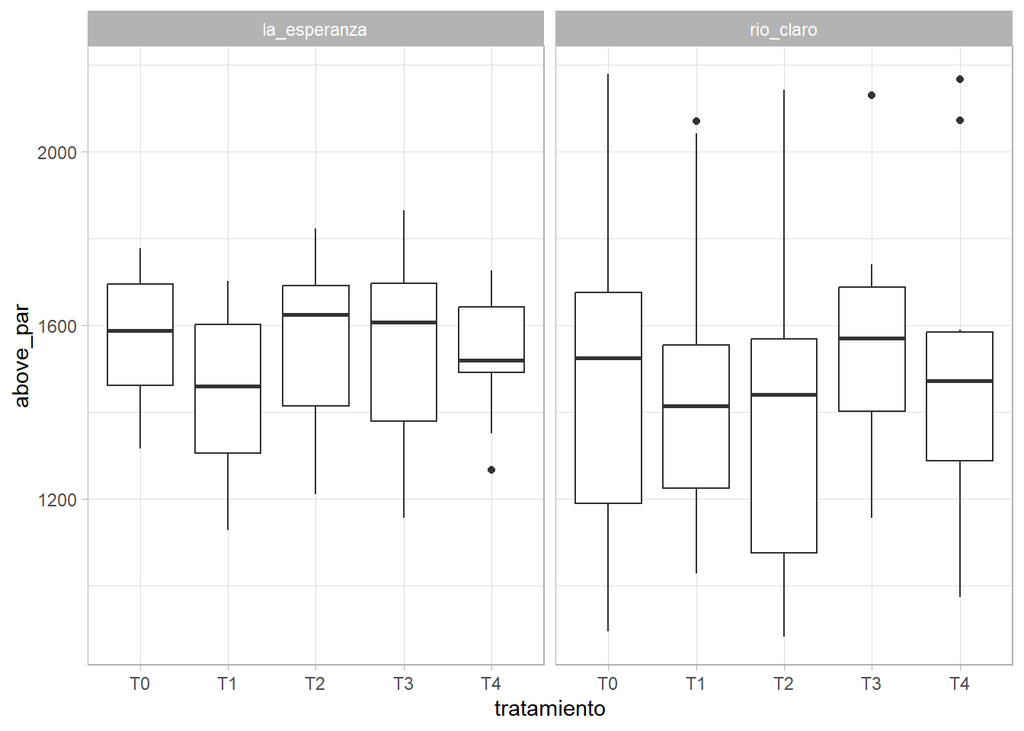

### Serie temporal

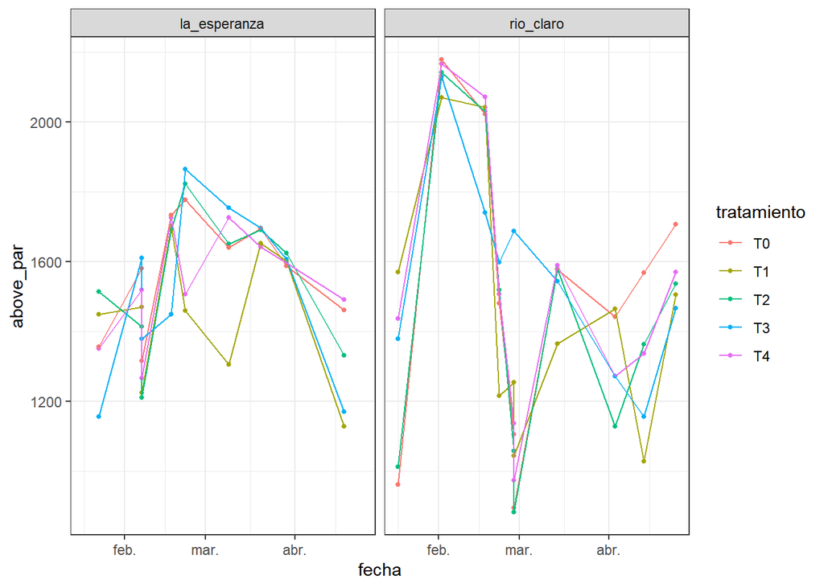

## Humedad del suelo

La siguiente tabla presenta la cantidad de dias de muestreo desde la instalación de los zim, el promedio de datos recopilados en cada uno de ellos, y el total recopilado durante toda la temporada por sitio. Los datos no contienen NA’s.

```
##          sitio n_dias n_datos_promedio n_datos_totales
## 1 la_esperanza    127            269.7           34250
## 2    rio_claro    127            244.1           31003
```

### Boxplot

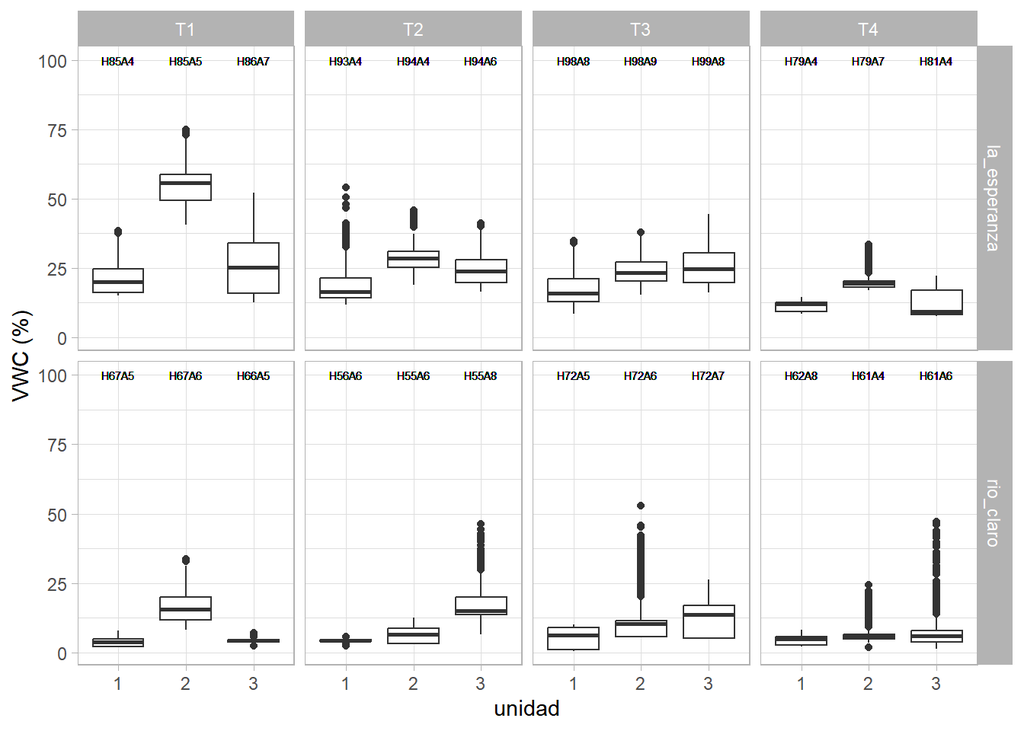

### Serie temporal

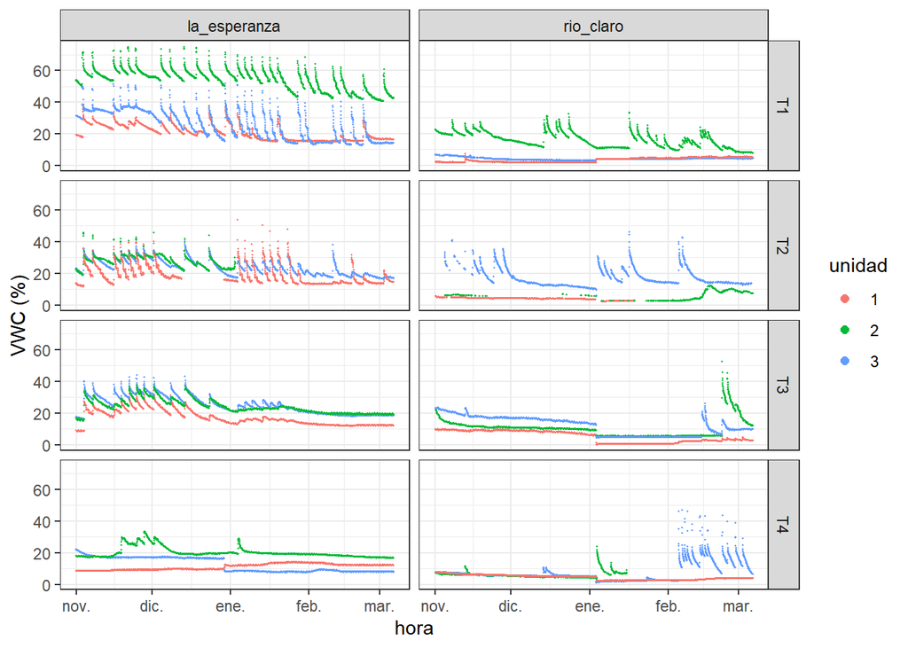

## Presión de parche

La siguiente tabla presenta la cantidad de dias de muestreo desde la instalación de los zim, el promedio de datos recopilados en cada uno de ellos, y el total recopilado durante toda la temporada por sitio. Los datos no contienen NA’s.

```
##          sitio n_dias n_datos_promedio n_datos_totales
## 1 la_esperanza    156            497.4           77590
## 2    rio_claro    156            480.2           74913
```

### Boxplot

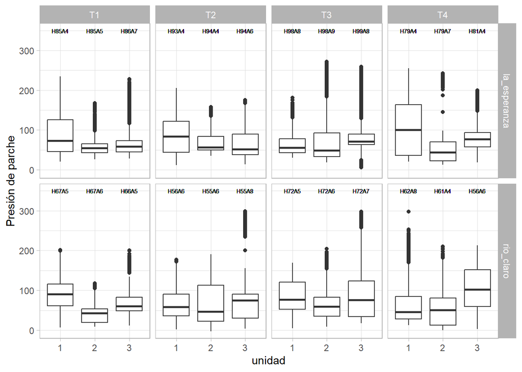

### Serie temporal

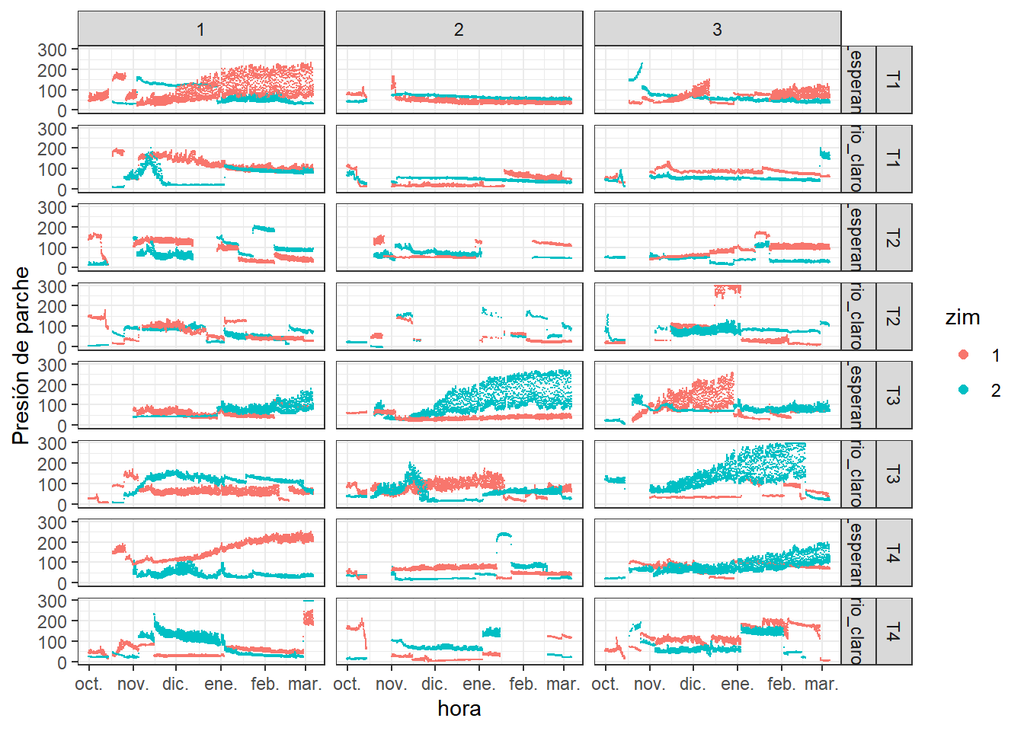

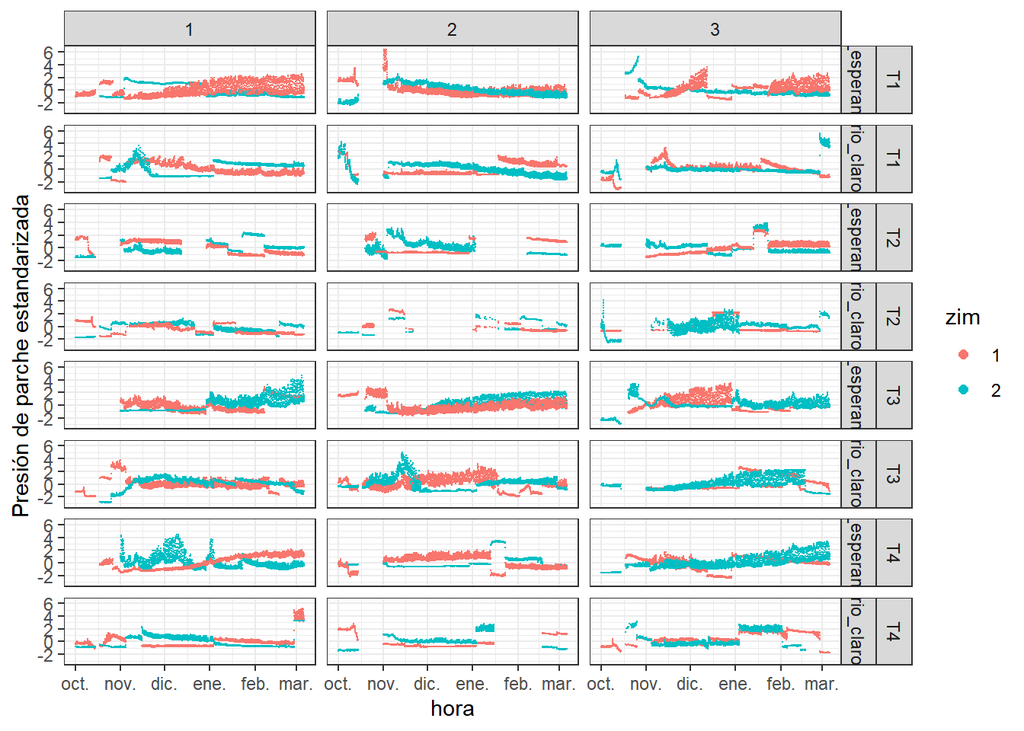

### Ciclo diario

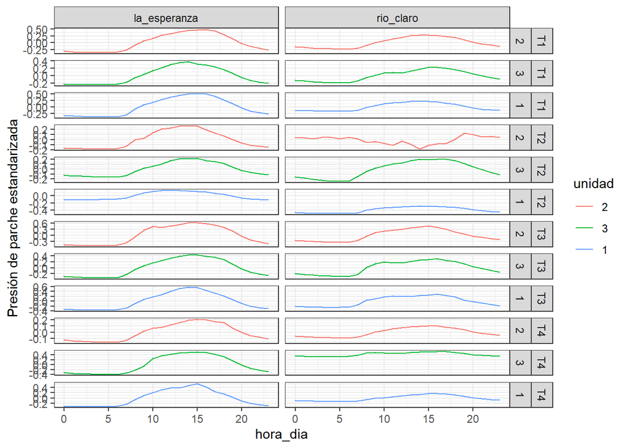